# Chapter 8 Homework

AP

2/5/2022

```r
library(tidyverse)
library(ggdag)
library(dagitty)
```

## Question 1

A path is open if all of the variables along that it are allowed to vary (i.e. are not controlled for). It is closed if at least one of the variables along that path has no variation either naturally or through manipulation.

## Question 2

X $\rightarrow$ A $\rightarrow$ Y (front door path)

X $\leftarrow$ B $\rightarrow$ Y (open back door path)

X $\rightarrow$ C $\leftarrow$ D $\rightarrow$ Y (closed back door path, because of collider C)

X $\rightarrow$ C $\leftarrow$ D $\rightarrow$ B $\rightarrow$ Y (closed back door path, because of collider C)

In order to identify the effect of X on Y, B must be controlled for.

## Question 3

The variables in the following diagram are health (hlt), income (inc), health habits (hab), environment (env), and personal history (hist).

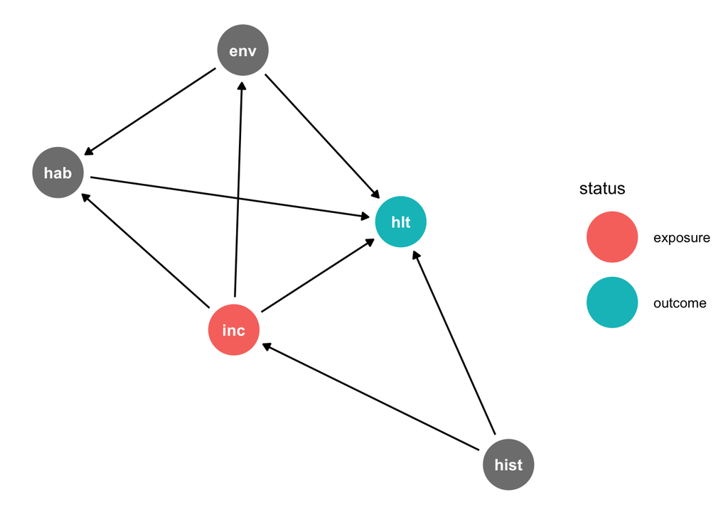

```r
q3dag <- dagify(hlt ~ inc + hab + env + hist,
       hab ~ inc + env,
       env ~ inc,
       inc ~ hist,
       exposure = "inc",
       outcome = "hlt"
      )
set.seed(18)
ggdag_status(q3dag) + theme_dag()
```

inc $\rightarrow$ hlt (front door, open, direct effect)

inc $\rightarrow$ env $\rightarrow$ hlt (front door, open, indirect effect)

inc $\rightarrow$ env $\rightarrow$ hab $\rightarrow$ hlt (front door, open, indirect effect)

inc $\rightarrow$ hab $\rightarrow$ hlt (front door, open, indirect effect)

inc $\rightarrow$ hab $\leftarrow$ env $\rightarrow$ hlt (back door, closed bc of collider “hab,” indirect effect)

inc $\leftarrow$ hist $\rightarrow$ hlt (back door, open, indirect effect)

Good Paths and Bad Paths depend on the research question, but assuming my question is “Does having higher income cause better health?” then the first four paths are Good, the fifth is Bad but already Closed, and the sixth is Bad and needs to be Closed by controlling for personal history.

## Question 4

Front Door Path

## Question 5

Popularity is a collider. Controlling for it would create a relationship between Teaching Quality and Number of Publications.

## Question 6

Lockdown $\rightarrow$ Recession (Front Door)

Lockdown $\rightarrow$ Unemployment $\rightarrow$ Recession (Front Door)

Lockdown $\leftarrow$ Prior Economy $\rightarrow$ Recession

Lockdown $\leftarrow$ Prior Economy $\rightarrow$ Unemployment $\rightarrow$ Recession

If we controlled for Unemployment, then the path Lockdown $\rightarrow$ Unemployment $\leftarrow$ Stimulus $\rightarrow$ Recession would open; we would see a relationship between Lockdown and Stimulus that’s more negative than before.

Because lockdowns often occur in phases, and have exceptions, the Lockdown variable would be hard to measure. Also, PriorEconomy is a bit vague.

GovernmentPriorities seems like a variable that should be included here.

## Question 7

more education $\leftarrow$ higher parents’ income $\rightarrow$ higher income

more education $\rightarrow$ better job $\leftarrow$ mentorship $\rightarrow$ higher income